# Block Bootstrap for Random Graphs

May 3, 2016

## Random graph stuff

## Preliminaries and notation

- A graph \(G\) is a mathematical object that consists of a set of vertices (nodes), \(V(G)\) and a set of edges (links), \(E(G)\). Let \(e_{ij} \in E(G)\) denote the edge between vertices \(i, j \in V(G)\).
- Throughout, \(n = |V(G)|\) is the number of vertices in \(G\) and \(e = |E(G)|\) the number of edges.
- The *degree* of vertex \(i \in V(G)\), \(d_i\) is the number of edges that are connected to vertex \(i\).
- We consider *undirected* (\(e_{ij} = e_{ji}\)) and *loopless* (\(i \not= j \forall e_{ij} \in E(G)\)) graphs.
- The distance \(dist(i, j)\) is the minimum number of edges in a connected path from \(i\) to \(j\) in \(G\).
- The \(d\)th order neighborhood of a vertex \(i \in V(G)\) is defined as \(N_d(u, G) = \{j \in V(G): dist(i, j) \le d\}\)

## Network inference

A complete description of a network and its topology is infeasible \(\Rightarrow\) we can study the statistics of a complex network (i.e., clustering coeffients, numbers of triangles, average degree, etc.)

Let

- \(G\) be a hypothetical undirected random graph,
- \(F = \{f(k), k \ge 0\}\) the degree distribution of \(G\),
- \(G_n\) be an observed realization of \(G\) of order \(n\) s.t. as \(n \rightarrow \infty\), the joint degree distributions of \(G_n\) approach the joint degree distribution of \(G\).
- \(d_1, \dots, d_n\) be the observed degrees of the vertices in \(G_n\).

**Goal**: Estimate the population mean degree of \(G\), \(\mu(G)\) using a block boostrap.

## A snowball's chance…

## Overview

- "Using the bootstrap for statistical inference on random graphs", Thompson, et. al. (2016)
- `snowboot` package on CRAN
- Estimation of mean degree from a sample of vertices using a *patchwork* sampling method - "labelled snowball sampling with multiple inclusions (LSMI)", from survey sampling
- *seeds* \(=\) initial random sample of single vertices  
  *patch* \(=\) formed by following paths of connected vertices emanating from the seed up to a certain distance  
  *wave* \(=\) increments in distance
- The degrees of all vertices visited in a patch are observed
- Boostrap *seeds* (randomly sample seeds with replacement and estimate the mean degree) or *non-seeds* (non-weighted or weighted selection)

## Estimator

\[T_n^* = \frac{\dfrac{1}{m}\sum_{q=1}^{m}d_q + D(1-\hat{p}_0)\dfrac{1}{m}\sum_{q=1}^m \tilde{A}_{NSq}}{\dfrac{1}{m}\sum_{q=1}^m 1 + D\dfrac{1}{m}\sum_{q=1}^m \tilde{B}_{NSq}}\]  
Where

- \(\hat{p}_0\) is the relative frequency of vertices of degree zero among the seeds,
- \(D\) is an arbitrary conbination factor depending on the degree distribution, for simplicity set \(D =\) the average degree of seeds.
- \(\tilde{A}_{NSq}\) and \(\tilde{B}_{NSq}\) are the wave-combined Horwitz-Thompson estimators of the sum of the degrees of all vertices in \(G_n\) and the number of vertices in \(G_n\) having positive degree, respectively.  
  \[\tilde{A}_{NSq} = \sum\limits_{w = 1}^d \sum\limits_{j \in \text{ wave } w \text{ of } q} 1 \text{ and } \tilde{B}_{NSq} = \sum\limits_{w = 1}^d \sum\limits_{j \in \text{ wave } w \text{ of } q} \frac{1}{d_j}\]

## Algorithm

**Data**: graph \(G_n\); number of seeds \(m\), \(m < n\); number of waves \(d\)  
**Result**: sample of \(m\) seeds with \(d\) waves around each seed.  
*seed* \(=\) randomly sample without replacement \(m\) vertices from \(G_n\)  
**for** \(q = 1, \dots, m\) **do**  
start with original \(G_n\) and \(seed_q\)  
**for** \(w = 1, \dots, d\) **do**  
\(wave_w =\) select all immediate neighbors using the existing edges  
remove the used edges  
**end**  
\(patch_q =\) join the current \(seed_q\) and all \(wave_w\) keeping the repeated elements  
**end**  
join all \(m\) patches, keeping all of the repeated elements

## Illustration

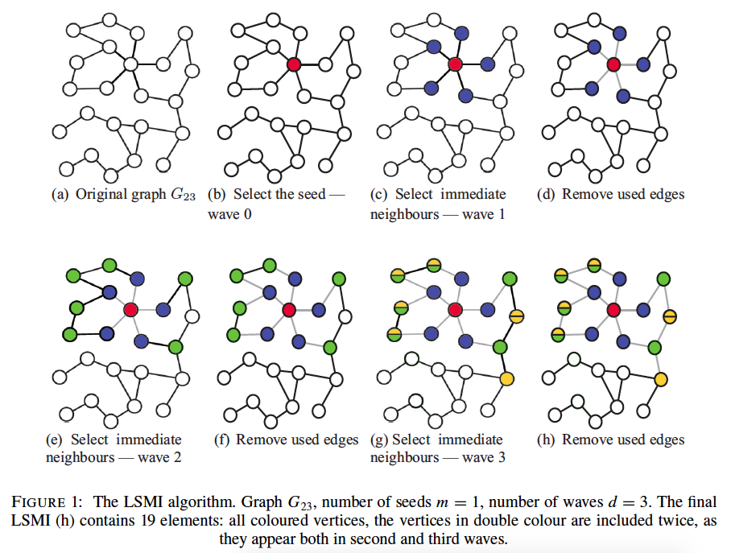

(Thompson et al. 2016)

## Properties

## A simpler idea

## Overview

## Algorithm

## Properties

## Simulated examples

## References

Cukier, Jerome. 2012. “Events in the Game of Thrones.” December. http://www.jeromecukier.net/projects/agot/events.html.

Martin, George RR. 2011. *A Dance with Dragons*. New York, NY, USA: Bantam Books.

Thompson, Mary E., Lilia L. Ramirez Ramirez, Vyacheslav Lyubchich, and Yulia R. Gel. 2016. “Using the Bootstrap for Statistical Inference on Random Graphs.” *Canadian Journal of Statistics* 44 (1): 3–24.